# ggplot 3.3.0 버전 업

최의용

2020 3 10

**출처: [Tidyverse-ggplot2 3.3.0](https://www.tidyverse.org/blog/2020/03/ggplot2-3-3-0/)**

# ggplot2 3.3.0

ggplot2 가 2020년 3월 5일에 3.3.0으로 업데이트가 되었다. ggplot을 조금 쓰고 있기는 하다만 막상 ggplot전체중 얼마나 쓰고 있냐고 물어보면 5%수준 정도도 안되는 사용향에 이번에 한번, 관심을 가져보고자 포스팅을 해보려 한다. 패키지가 업데이트 되어 install.packages(“ggplot2”) 로 재설치 하면 됬으나, Mac의 경우에는 remove.packages(“ggplot2”)를 진행하고 설치를 다시 했어야 하더라. 그럼 이제 하나씩 추가된 기능을 소개해보도록 하겠다.

# X축, Y축의 라벨 겸칩에서 해방

기존 x축을 표현할때 텍스트가 길어지면 겹쳐서, 어쩔수 없이 각도에 변화룰 주어야 했었다. 그러나 이번에 추가된 기능으로는 guide_axis()가 생겼다.

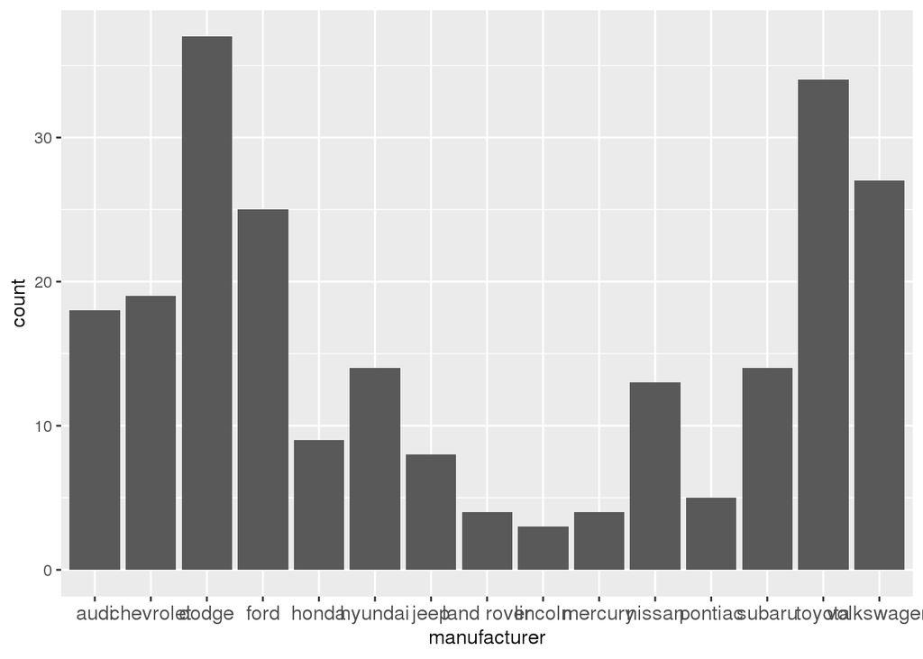

```r
library(ggplot2)
library(patchwork)

p <- ggplot(mpg) +
  geom_bar(aes(x = manufacturer)) +
  theme(axis.text.x = element_text(size = 11))

# Overlapping labels
plot(p)
```

### label 겹치는 문제 해결

기존 코드에 **scale_x_discrete(guide = guide_axis(n.dodge = 2))**를 추가 해주어 label의 겹침을 해결 할 수 있다.

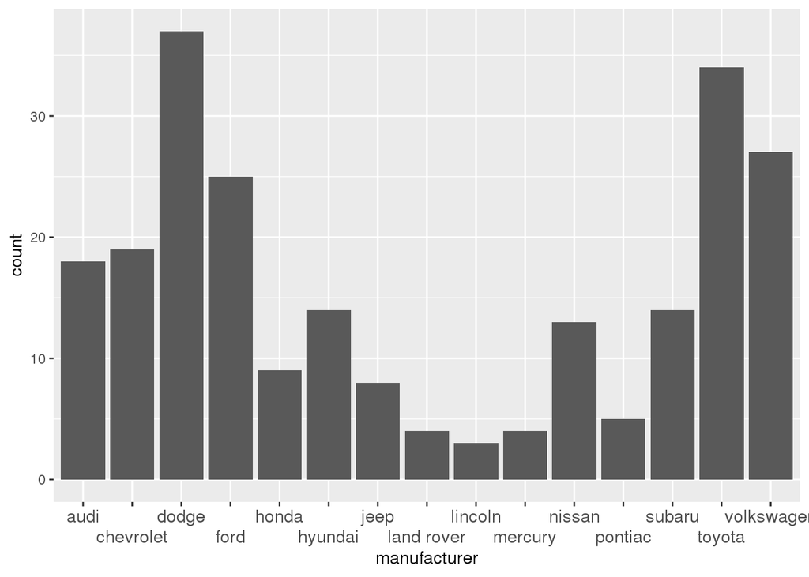

```r
# Use guide_axis to dodge the labels
p +
  scale_x_discrete(guide = guide_axis(n.dodge = 2))
```

### 겹치는 label 제거

또는 **scale_x_discrete(guide = guide_axis(check.overlap = TRUE))** 코드를 사용하여 겹치는 부분을 제거 할 수 있다.

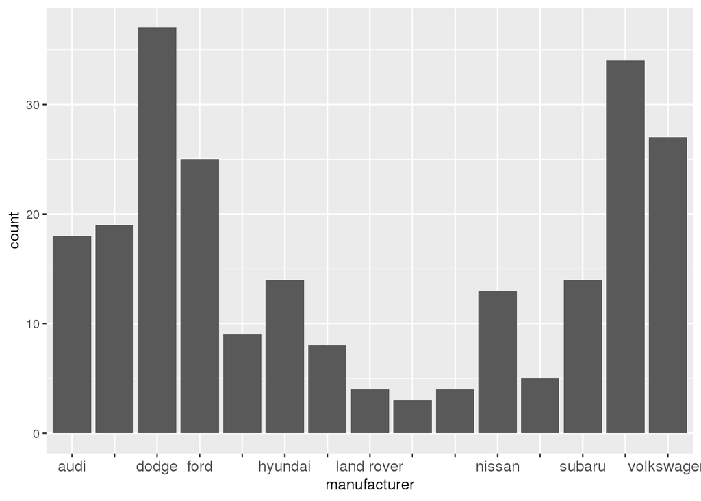

```r
# Or to remove overlapping labels
p +
  scale_x_discrete(guide = guide_axis(check.overlap = TRUE))
```

# 새로운 scale 의 등장 : scale_*_binned()

**scale_( )_discrete** & **scale_( )_continuous** 에 이은 3번째 scale이 추가 되었다.

```r
p <- ggplot(mpg) +
  geom_point(aes(displ, cty, size = hwy, colour = hwy))
```

### 연속형 데이터에 이산형 크기로 구분 짓기 가능

**scale_size_binned()**를 사용하면서 연속형데이터인 hwy에 대해 단계적으로 구분을 지어 크기로 표현을 할 수가 있다.

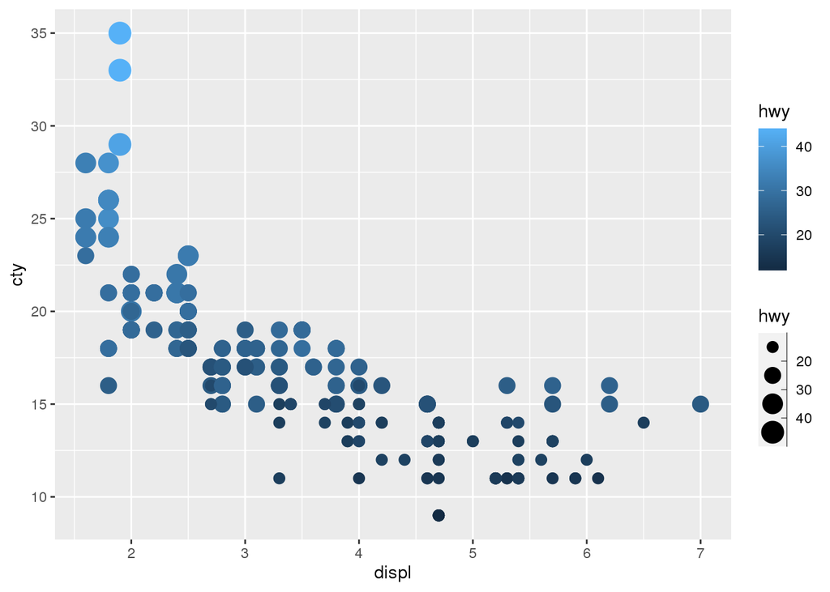

```r
p +
  scale_size_binned()
```

### 연속형 데이터에 이산형 컬러로 구분 짓기 가능

**scale_colour_binned()**를 사용하면서 연속형으로 표현하는 hwy (파란색 label)을 구분 지어줄 수 있다.

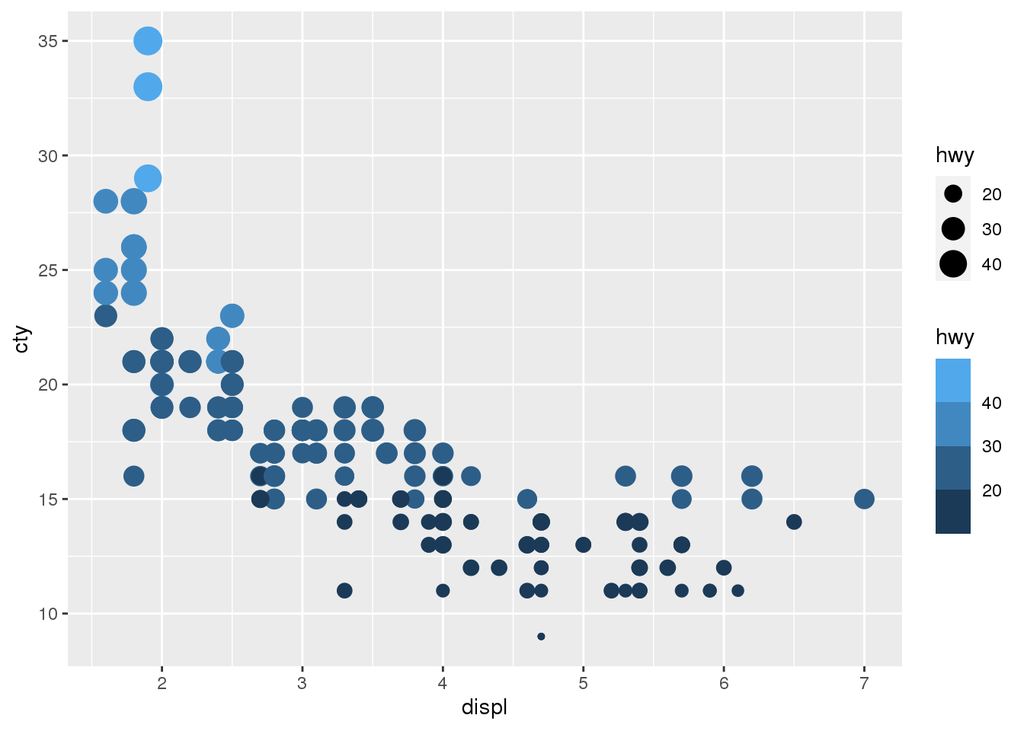

```r
p +
  scale_colour_binned()
```

### scale_size_binned

이산형 binning 처리에 항상 애매한 문제가 되는 경계값도 legend에 표기가능!

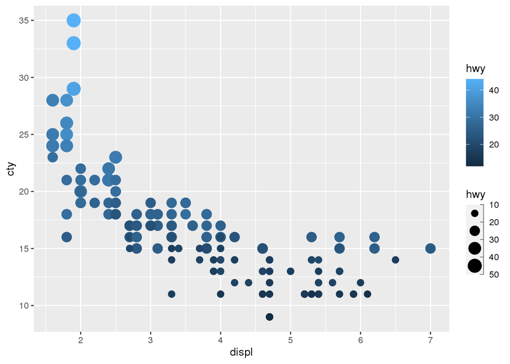

```r
p +
  scale_size_binned(guide = guide_bins(show.limits = TRUE))
```

### 연속형 데이터를 x축 방향으로 정렬시킴

**scale_x_binned()**는 x축방향으로 정렬시켜 막대플롯을 연상시키듯 사용할 수가 있다.

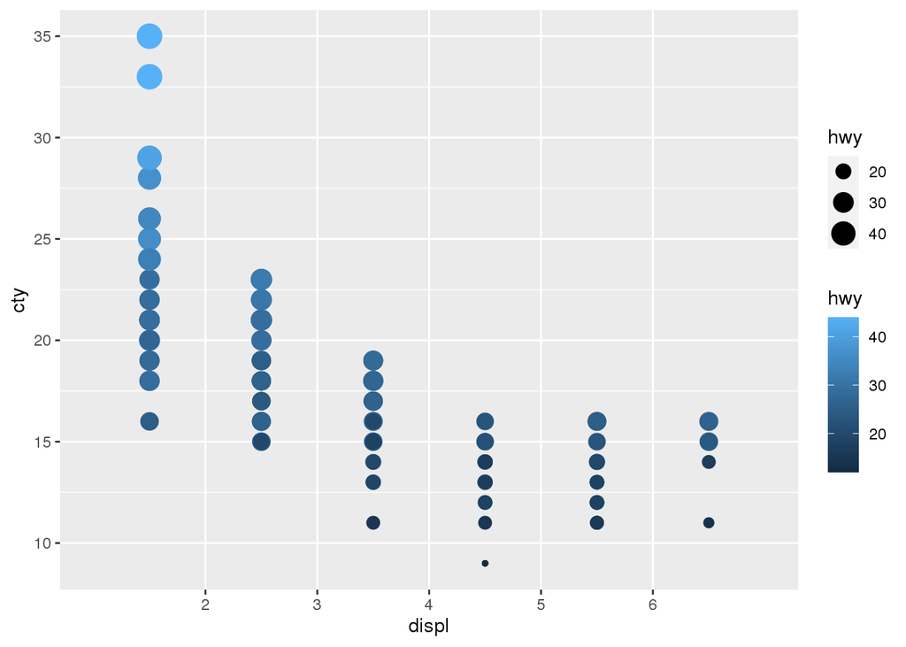

```r
p +
  scale_x_binned()
```

#### scale_x_binned과 막대그래프 표현

scale_x_binned과 막대그래프를 동시에 사용한 모습이다.

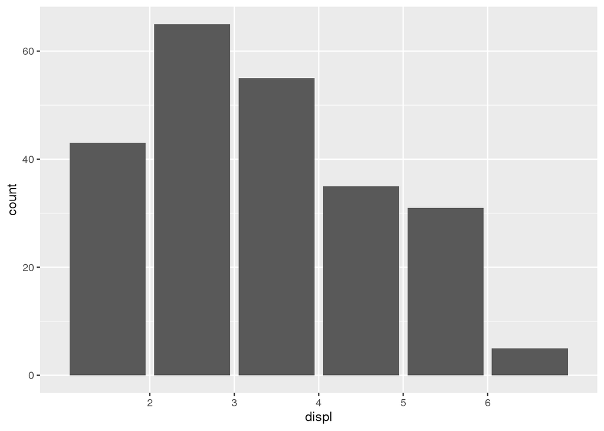

```r
ggplot(mpg) +
  geom_bar(aes(displ)) +
  scale_x_binned()
```

# 차트 축 돌리기 (coord_flip()의 대안)

기존에 ggplot2에서 x축과 y축을 바꾸려면 coord_flip()를 사용해야 했으며, 당시에 나에게는 이것조차 새로운 세계였다. 그러나 이제는 이를 좀 더 직관적으로 사용할 수가 있게 되었다.

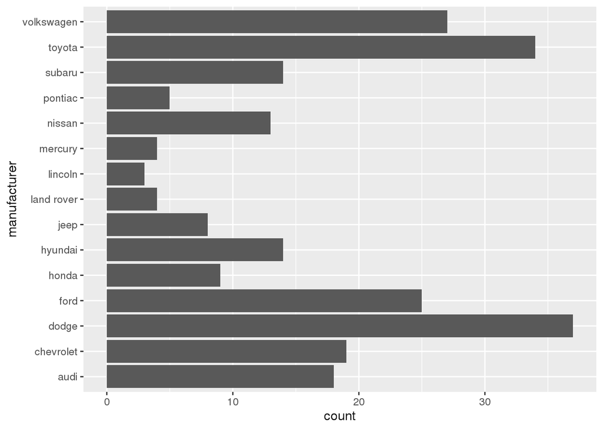

```r
ggplot(mpg) +
  geom_bar(aes(x = manufacturer)) +
  coord_flip()
```

### default로 y만 선택이 가능하다

ggplot의 특성상 default에 x가 들어가야 했던것이 y로 지정해주어 가로에서부터 표현을 할 수 있게 해주었다. (그러나 음… 막상 이기능은 직관적이지 못하다는 인상을 줄 수 있을것 같다. 늘 그렇듯이 dafault는 x라는 생각을 하기 때문인가 보다.)

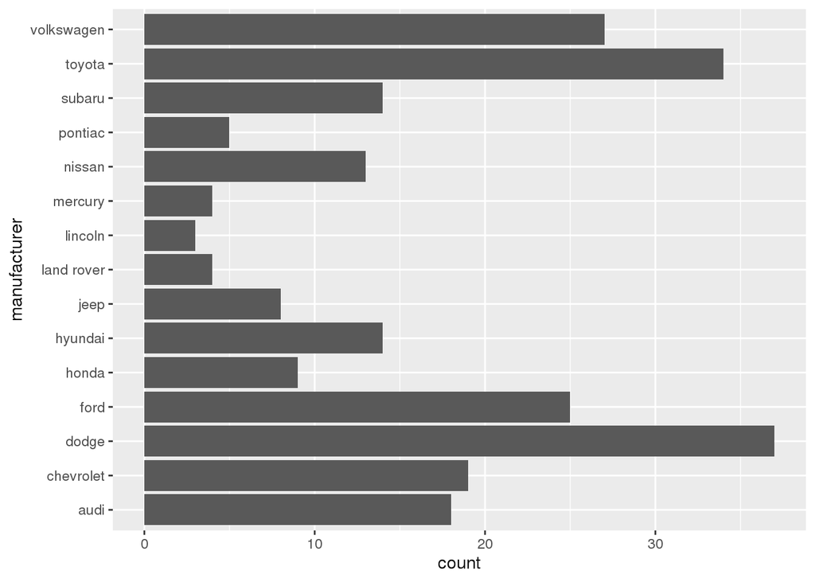

```r
ggplot(mpg) +
  geom_bar(aes(y = manufacturer))
```

### geom_smooth 역시 y관점에서 설정이 가능하다

글로벌하게 적용되는 aes 가 아닌 geom_* 함수의 orientation 아규먼트를 통해 개별 geom 단위로 처리하는 것도 가능

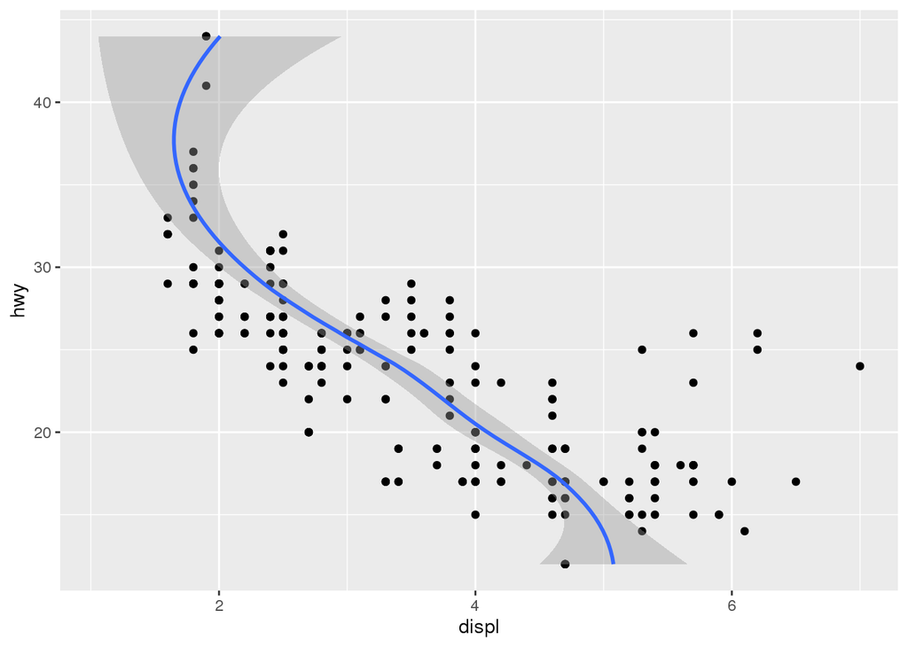

```r
ggplot(mpg, aes(displ, hwy)) +
  geom_point() +
  geom_smooth(orientation = "y")
```

# 좀더 심미적인 그래프

사실, 아까도 말했지만 ggplot의 5%남짓 밖에 사용하지 못하는 나에게도 충분히 이쁜 그래프를 표현할 수 있다고 생각 했었다. 그럼에도 이번에 그래프를 그리는데에 있어, 조금더 이쁜 표현을 설정할 수 있는 기능을 추가 해주었다.

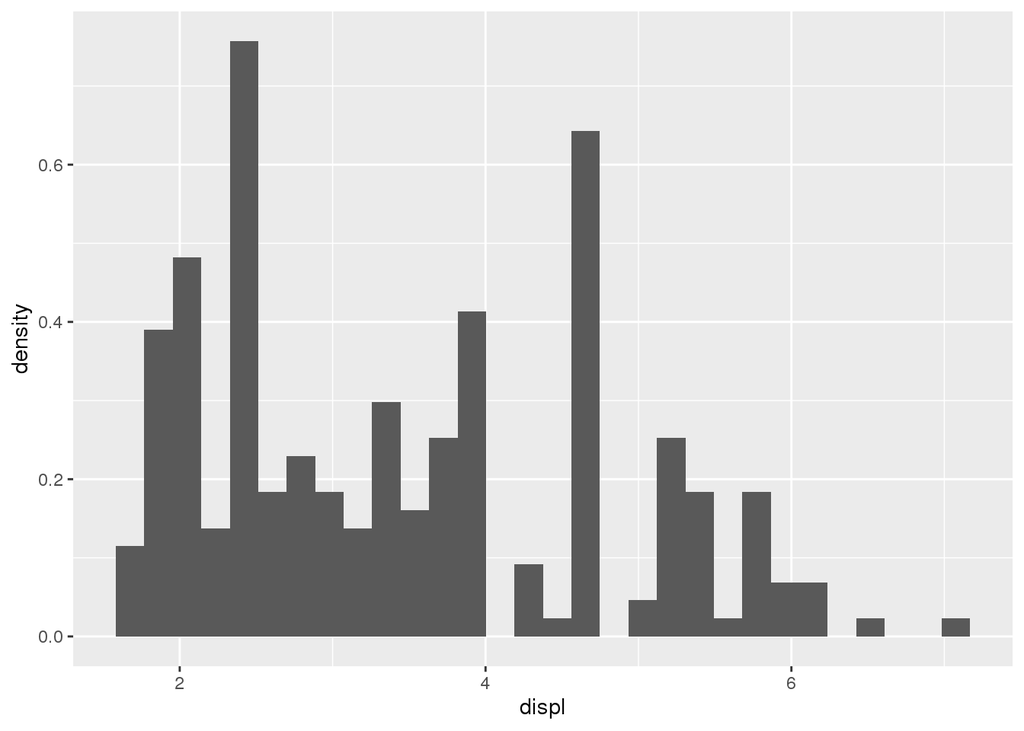

```r
ggplot(mpg, aes(displ)) +
  geom_histogram(aes(y = after_stat(density)))
```

### 내부를 색으로 채우는 코드

**after_scale()**코드를 사용하여 내부를 색으로 표현이 가능하다.

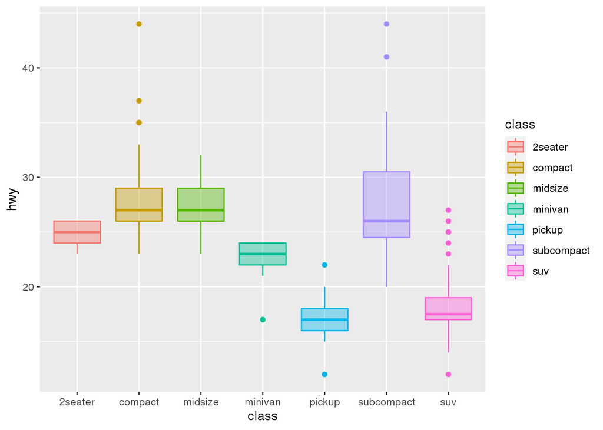

```r
ggplot(mpg, aes(class, hwy)) +
  geom_boxplot(aes(colour = class, fill = after_scale(alpha(colour, 0.4))))
```

### 하나의 aes 에 여러개의 mapping을 하는 것도 이제 가능함

**stage()** 기능을 사용.

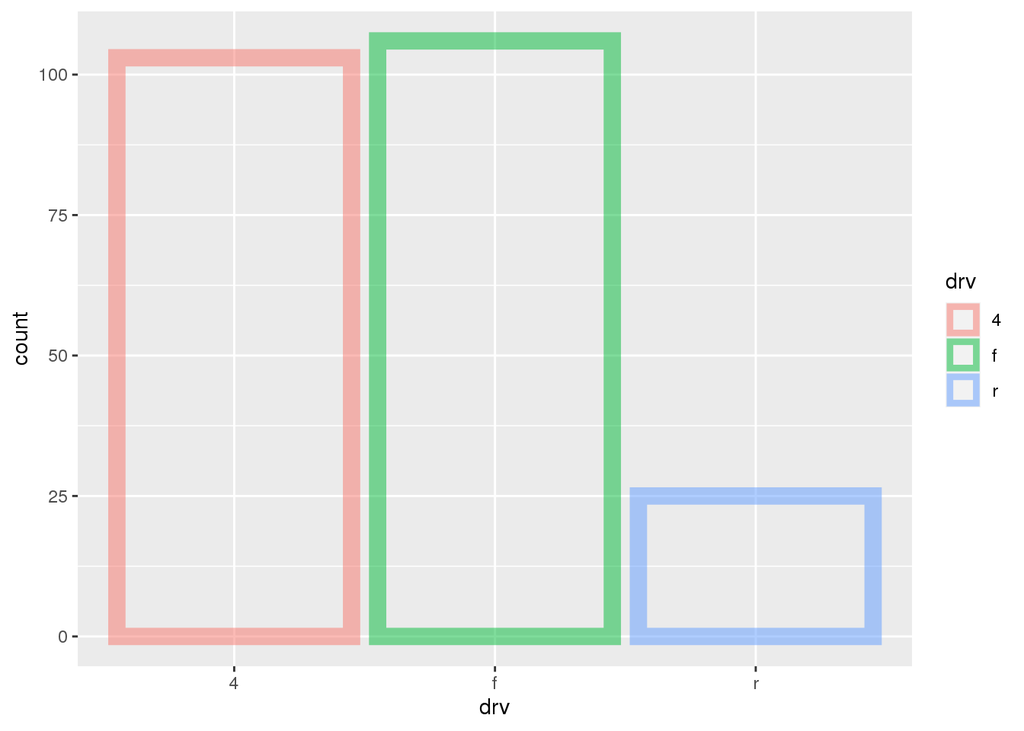

```r
ggplot(mpg) +
  geom_bar(
    aes(
      x = drv,
      colour = stage(start = drv, after_scale = alpha(colour, 0.5))
    ),
    fill = NA, size = 4
  )
```

# 자유롭게 확장 가능한 테마

이 부분은 아직 테마 설정에 대해서 나 역시 자유롭지 못하기에 제대로 이해를 할 수가 없었다.

```r
register_theme_elements(
  ggrelfacet.panel.arrow = element_line(
    size = 3, arrow = arrow()
  ),
  element_tree = list(
    ggrelfacet.panel.arrow = el_def("element_line", "line")
  )
)
```

# 더 나아진 윤곽 계산

geom_polygon 을 통한 contour 처리는 inner hole 및 next level contour 처리가 안되기에 그래픽이 쪼개진 폴리곤으로 망가져보였다. 이제 geom_contour_* 를 이용하면 깔끔한 처리가 가능해졌다.

### Step 1.

윤곽을 계산하는데 있어 보다 선명한 표현을 할 수 있게 되었다. 다음 그림을 보자. 등고선을 표현하려고 하는데 직관적이지도 뚜렷하지도 않다.

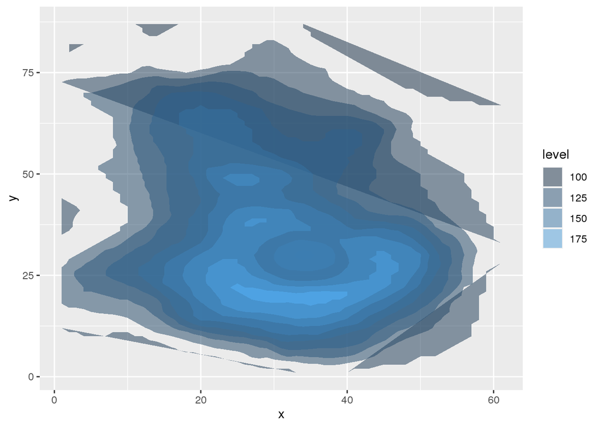

```r
volcano_long <- data.frame(
  x = as.vector(col(volcano)),
  y = as.vector(row(volcano)),
  z = as.vector(volcano)
)

ggplot(volcano_long, aes(x, y, z = z)) +
  geom_polygon(aes(fill = stat(level)), alpha = 0.5, stat = "contour") +
  guides(fill = "legend")
```

### Step 2.

**geom_contour_filled()** 함수를 사용하여 조금 더 선명한 표현을 할 수 있었다.

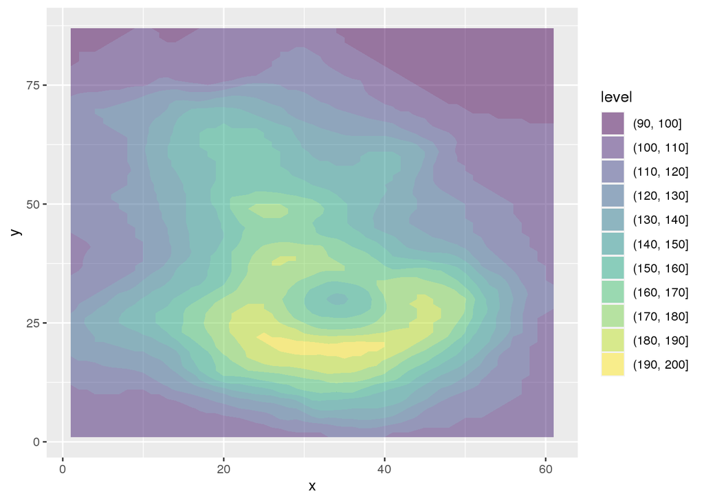

```r
ggplot(volcano_long, aes(x, y, z = z)) +
  geom_contour_filled(aes(fill = stat(level)), alpha = 0.5)
```

### Step 3.

이번에 이 모든 문제가 해결되었다. 위 그림과 다른점은 범례를 표현하는데, 연속적인 표현을 이산화 해서 표현을 하였다.

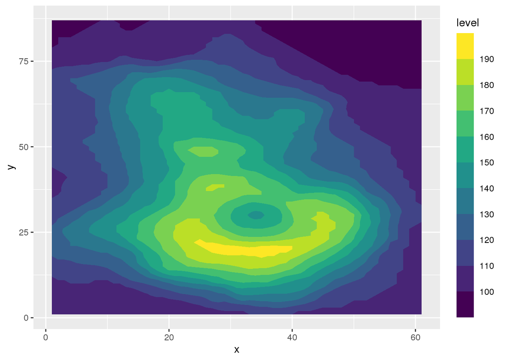

```r
ggplot(volcano_long, aes(x, y, z = z)) +
  geom_contour_filled(aes(fill = stat(level))) +
  guides(fill = guide_colorsteps(barheight = unit(10, "cm")))
```

# 그외 추가된 기능

- geom_ribbon, area, density 의 outline stroke 처리 (외곽선 처리)
- outline.type 아규먼트를 통해 명시적 처리가능
- upper, lower, both, full 등 4가지 타입 제공

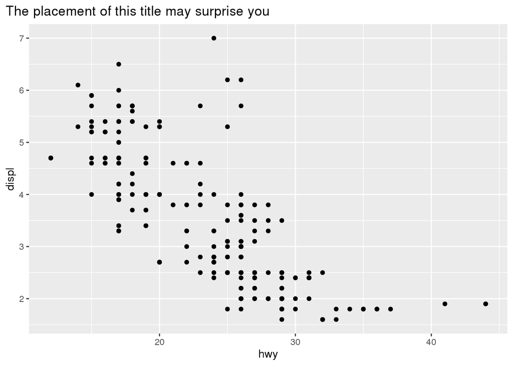

```r
ggplot(mpg) +
  geom_point(aes(hwy, displ)) +
  ggtitle("The placement of this title may surprise you") +
  theme(plot.title.position = "plot")
```

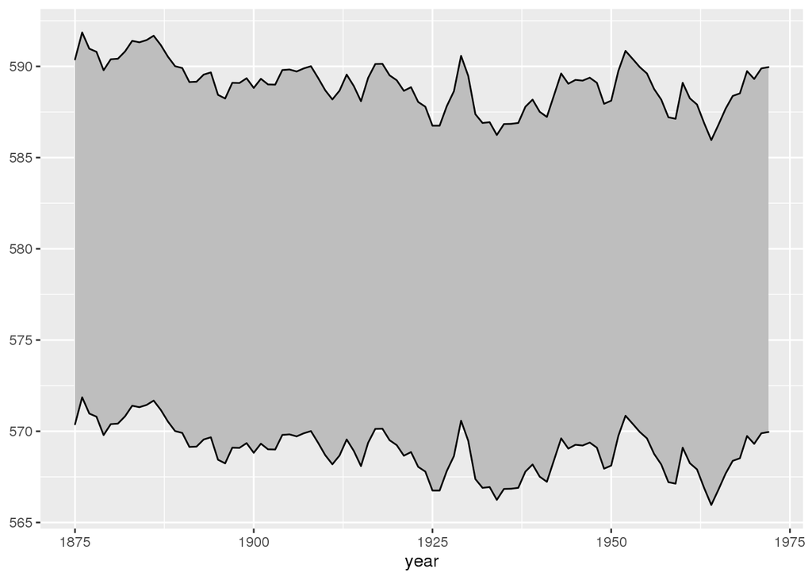

```r
huron <- data.frame(year = 1875:1972, level = as.vector(LakeHuron))
ggplot(huron, aes(year)) +
  geom_ribbon(aes(ymin = level - 10, ymax = level + 10), fill = "grey", colour = "black")
```

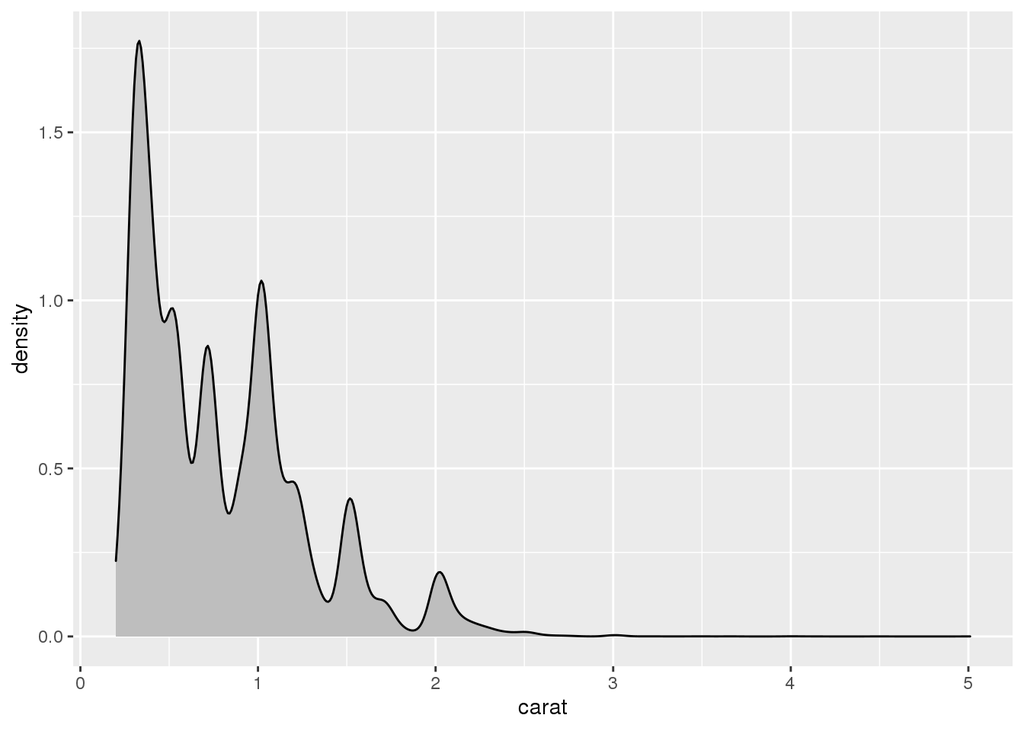

```r
 ggplot(diamonds, aes(carat)) +
  geom_density(fill = "grey")
```

# 총평

처음으로 새로운 버전에 대해 리뷰를 했다. 아직 많이 미숙해서 제대로 리뷰가 안되었으나 **하헌철**님의 도움으로 조금 더 전문적인 리뷰를 할 수 있게 되었다. 다음에는 일기처럼 쓰는게 아니라 좀 더 전문적으로 리뷰를 쓰는쪽으로 노력을 해봐야 겠다.